# Assn_6

Emily Bierbaum

2022-11-11

## **Assignment #6**

#### Load the required libraries

```r
require(tidyverse)
```

#### Import the csv file

```r
MBT_ebird<-read.csv("Data/MBT_ebird2.csv")
```

#### **(1a)** Using the ebird dataset, calculate the number of species seen each month of each year in each location.

- Group the csv files by location, month, and year
- Then we will summarize the groups by species count
- `Length ()` function calculates the length of lists/vectors that have *unique* common names
- `.group="drop"` is used because the output becomes ungrouped

```r
bird_stats<- MBT_ebird %>%
  group_by(location, month, year) %>%
  summarize(species_count = length(unique(common_name)), .groups = "drop")
```

#### **(1b)** Plot the number of species seen each month with the color of the points indicating year and facet this plot by location

- Create a `ggplot` using the data above, `bird_stats`
- `aes` specifies the variables to be plotted
- `as.factor` is needed or else the months are in increments of 0.5
- `facet_wrap` generates multiple plots based on location
- The geometric is drawn in points and the axes and title were labeled
- The figure legend will be for year
- Lastly, I changed the color gradient to rainbow

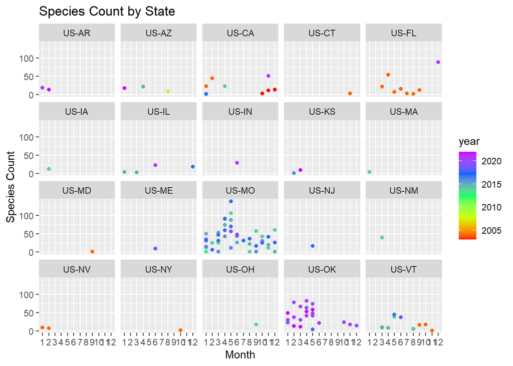

```r
prob1 <- ggplot(data = bird_stats)+
  aes(as.factor(month), species_count, color = year) +
  facet_wrap(~location) +
  geom_point(size=1.5) +
  theme_gray() +
  xlab("Month") +
  ylab("Species Count") +
  ggtitle("Species Count by State")

problem1<-prob1+scale_color_gradientn(colours = rainbow(5))
problem1
```

#### *Using the data set from Assignment #5:*

#### **(2)** Plot a comparison of mass by treatment including the individual observations, the mean, and standard error of the mean. Use point color or shape to indicate the sex.

```r
mass_treat<-read.csv("Results/Combined_Assn5_Data.csv")

prob2 <-ggplot(data= mass_treat,aes(Group,mass)) +
  geom_jitter(size = 2, aes(Group, mass, color=Sex)) +
  xlab("Group") +
  ylab("Mass") +
  stat_summary(fun = mean,
               geom = "crossbar",
               width = 0.5,
               color = "purple") +
  stat_summary(geom = "errorbar",
               width = 0.6)+
  ggtitle("Mass by Group and Sex")
  labs(color="Sex")
```

```
## $colour
## [1] "Sex"
##
## attr(,"class")
## [1] "labels"
```

```r
prob2
```

```
## No summary function supplied, defaulting to `mean_se()`
```

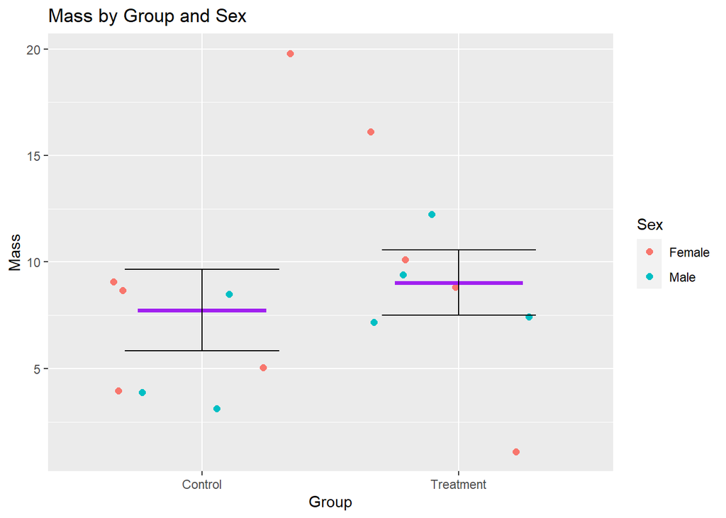

#### **(3)** Generate a scatter plot of age and mass, indicate treatment with point shape or color, and fit separate regression lines (without CI) to each treatment.

- Create a `ggplot` of the data frame with age and mass as the variables
- Want geometric plot as points and create a figure legend for group (dots)
- Label the axes and the title
- `geom_smooth` adds a trend line and `method=lm` plots a linear model (linear regression line)
- `se=false` removes the plotting of a confidence interval around the line
- The `labs()` function sets the group (control vs treatment) as the figure legend for the linear model

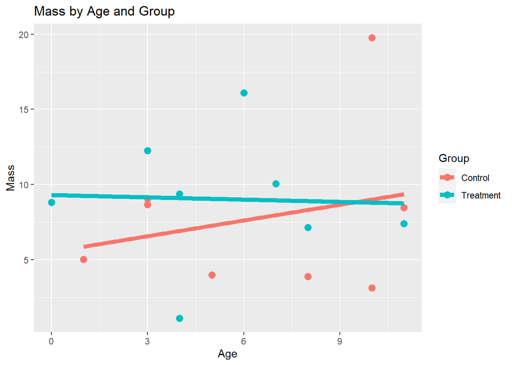

```r
prob3<-ggplot(data= mass_treat,aes(age,mass) )+
  geom_point(size =3, aes(age, mass, color=Group))+
  xlab("Age")+
  ylab("Mass")+
  geom_smooth(size = 2, method = lm,
              aes(color = Group,  group = Group),
              se=FALSE)+
  labs(color="Group") +
  ggtitle("Mass by Age and Group")

prob3
```

#### **(4)** Combine the plots from question 2 and 3 using patchwork tag each panel with, and number or letter and include a title for the overall plot.

- Download the library `patchwork`
- `plot_annotation` adds the two plots together and adds a title over them both
- The plots are then labeled A and B

```r
require(patchwork)
```

```
## No summary function supplied, defaulting to `mean_se()`
```

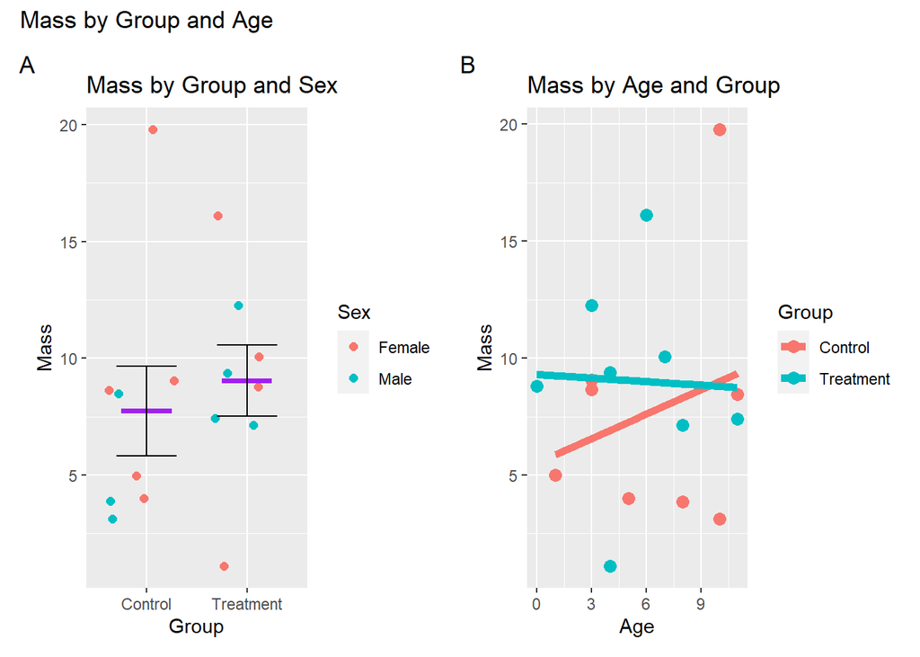

```r
prob2+prob3+plot_annotation(title = "Mass by Group and Age",
                              tag_levels = "A")
```